# **Diplomado IA: Inteligencia Artificial II - Parte 2**. Práctico 1: Modelos con memoria externa

**Profesor:** Andres Espinosa (aespinosa1@uc.cl)

# Introducción

En este *notebook* implementaremos el modelo del trabajo [Key-Value Memory Networks for Directly Reading Documents](https://arxiv.org/abs/1606.03126) aplicado en la tarea de Question Answering (QA). Específicamente, utilizaremos el set de datos [WikiMovies](https://research.fb.com/downloads/babi/), que contiene preguntas y respuestas sobre películas.

El contenido de este *notebook* está basado principalmente en [esta implementación](https://github.com/berlino/MemNN) en PyTorch, y también tomó algunos elementos de la [implementación original](https://github.com/facebook/MemNN/tree/master/KVmemnn) (escrito en Torch/Lua). La implementación final con todos los cambios/mejoras necesarias la pueden encontrar [acá](https://github.com/andresespinosapc/MemNN), pero en este *notebook* la simplificaremos más todavía.

Como ya vimos en la clase, el modelo que vamos a implementar tiene una base de conocimiento estructurada como keys y values, y tiene un controlador que se encarga de aprender cómo utilizar esta base de conocimiento para responder a las preguntas, utilizando el key para encontrar las entradas que necesita y los values como valores que va guardando en su representación interna para responder.

# Carga de datos

## Instalar librerías

```python
!pip install torchfile
!pip install flashtext
```

```
  Preparing metadata (setup.py) ... done
  Preparing metadata (setup.py) ... done
```

## Importar librerías

```python
import os
from tqdm import tqdm
import torchfile
```

## Descargar datos

Primero descargamos los datos. Luego de descargarlos, tendremos los siguientes archivos:

- `train_1.txt`: Datos de entrenamiento. En cada línea está primero la pregunta y luego la respuesta, separadas por un `\t`.
  - Ejemplo de una línea:
    - `1 what movies are about ginger rogers ? 1:what 1:movies 1:are 1:about 1:ginger rogers 1:? \t Top Hat, Kitty Foyle, The Barkleys of Broadway`
  - Hasta el primer `?` es la pregunta original.
  - Después sigue la pregunta tokenizada: `1:what` es un token, `1:ginger rogers` es otro token
  - `Top Hat, Kitty Foyle, The Barkleys of Broadway` es la respuesta
- `dev_1.txt`: Datos de validación, mismo formato anterior.
- `test_1.txt`: Datos de prueba, mismo formato anterior.
- `entities_1.txt`: Archivo en que cada línea tiene una entidad que hay en los datos. Son una mezcla de nombre de actores, de películas, etc.

  - ```
      Jean Marais
      FM
      Kervin Harkey
      ...
    ```

- `wiki-w=0-d=3-i-m.txt`: Base de conocimiento. Está construída de la siguiente forma: Se utilizan documentos de Wikipedia en que el título sea el nombre de una película. Se itera sobre todas las entidades que hayan en el texto y se genera una ventana con las 3 palabras antes y 3 palabras después de la entidad. Para cada una de estas ventanas se guardan dos entradas en la base de conocimiento:
  1. Un *key* compuesto del token `__MOVIE__` concatenado con la ventana. El *value* correspondiente es el nombre de la película.
  2. Un *key* compuesto del token `__WINDOW_CENTER__` concatenado con el nombre de la película y la ventana. El *value* correspondiente es la entidad central de la ventana.

  Ejemplo:

  - ```
      1 __WINDOW_CENTER__ 1:Marathon Man 1:( film 1:) 1:Marathon Man 1:is \t film
      2 __MOVIE__ 1:( film 1:) 1:Marathon Man 1:is \t Marathon Man
      ...
    ```

  ```
  - Cada línea es una entrada tokenizada de la base de datos, `__WINDOW_CENTER__` es un token, `1:(` es otro token.
  - Lo que está antes del `\t` es el `key` y lo que está después es el `value`.
  ```

Pueden ver que hay algunos tokens antecedidos por un `1:`, esto indica que son tokens distintos, por ejemplo `1:movie` no es el mismo token que `movie`, y se usa para que los embeddings de los tokens de las `keys` sean distintos a los embeddings de los tokens de los `value`. Por ejemplo, si en el arhivo de la knowledge base estuviese la entrada (línea) `1:movie \t movie`, el embedding de `1:movie` es distinto al embedding de `movie`.

En la carpeta `torch` se encuentran los mismos datos ya vectorizados.

```python
%%time
# Dataset original
!wget https://www.dropbox.com/s/z4x24ubfiq27bu3/movieqa.tar.gz
!tar -xzvf movieqa.tar.gz && rm movieqa.tar.gz
```

[output not shown]

[output cut: 64 more lines]

```
movieqa/questions/wiki_entities/categories/wiki-entities_qa_movie_to_language_test.txt
movieqa/questions/wiki_entities/categories/wiki-entities_qa_movie_to_director_test.txt
movieqa/questions/wiki_entities/categories/wiki-entities_qa_movie_to_imdbrating_test.txt
movieqa/questions/wiki_entities/categories/wiki-entities_qa_movie_to_year_test.txt
movieqa/questions/wiki_entities/categories/wiki-entities_qa_movie_to_imdbrating_dev.txt
movieqa/questions/wiki_entities/categories/wiki-entities_qa_movie_to_writer_test.txt
movieqa/questions/wiki_entities/categories/wiki-entities_qa_tag_to_movie_dev.txt
movieqa/questions/wiki_entities/categories/wiki-entities_qa_tag_to_movie_test.txt
movieqa/questions/wiki_entities/categories/wiki-entities_qa_movie_to_imdbvotes_test.txt
movieqa/questions/wiki_entities/categories/wiki-entities_qa_movie_to_tags_test.txt
movieqa/._.DS_Store
movieqa/._README.txt
movieqa/._LICENSE.txt
CPU times: user 17.7 ms, sys: 7.61 ms, total: 25.3 ms
Wall time: 3.93 s
```

```python
%%time
# Dataset ya tokenizado y vectorizado
!wget https://www.dropbox.com/s/nzq4ryzlgnkd3oa/data.tar.gz
!tar -zxvf data.tar.gz && rm data.tar.gz
```

[output not shown]

```python
%%time
# Carpeta con algunos datos ya preprocesados, como la lista de tokens
!wget https://www.dropbox.com/s/3cec2wx5ff5sve8/pkl.tar.gz
!tar -zxvf pkl.tar.gz && rm pkl.tar.gz
```

[output not shown]

```python
%%time
# Pesos del modelo ya entrenado
!wget https://www.dropbox.com/s/og1d9hqg2tokjb7/best_state.pt
```

[output not shown]

```python
# Datos ya preprocesados
!wget https://www.dropbox.com/s/ya093cezv9z9njw/train_data.pkl
!wget https://www.dropbox.com/s/u80qtuy5zppvrlj/dev_data.pkl
!wget https://www.dropbox.com/s/g6469csz4cfwgan/test_data.pkl
```

[output not shown]

[output cut: 16 more lines]

[output not shown]

## Cargar los datos

En la siguiente celda simplemente se cargan los datos ya vectorizados, para no tener que hacer el proceso de vectorización. La vectorización se hace simplemente tokenizando y transformando cada token a un id único.

El único procesamiento especial que se hace es que se crean 2 tokens distintos para cada entidad, como se explicó en la sección "Descargar datos"

```python
import torchfile

DATA_DIR = 'data'

train_file = DATA_DIR + "/torch/train_1.txt"
dev_file = DATA_DIR + "/torch/dev_1.txt"
test_file = DATA_DIR + "/torch/test_1.txt"
wiki_file = DATA_DIR + "/torch/wiki-w=0-d=3-i-m.txt"

train_x = torchfile.load(train_file + ".vecarray.x")
train_y = torchfile.load(train_file + ".vecarray.y")
dev_x = torchfile.load(dev_file + ".vecarray.x")
dev_y = torchfile.load(dev_file + ".vecarray.y")
test_x = torchfile.load(test_file + ".vecarray.x")
test_y = torchfile.load(test_file + ".vecarray.y")
wiki_x = torchfile.load(wiki_file + ".hash.facts1_va")
wiki_y = torchfile.load(wiki_file + ".hash.facts2_va")
wiki_ind_ = torchfile.load(wiki_file + ".hash.facts_ind")
wiki_hash_ = torchfile.load(wiki_file + ".hash.facts_hash_va")

def get(x, i):
    start = int(x[b"idx"][i]) - 1
    length = int(x[b"len"][i])
    ret = x[b"data"][start : start + length]
    return [ int(x) -1 for x in ret]

def extract(x,y):
    q = []
    a = []
    l = int(x[b"cnt"][0])
    for i in range(l):
        q_ = get(x,i)
        a_ = get(y,i)
        q.append(q_)
        a.append(a_)
    return q, a

# Preguntas y respuestas para cada uno de los sets de datos
train_q_orig, train_a_orig = extract(train_x, train_y)
dev_q_orig, dev_a_orig = extract(dev_x, dev_y)
test_q_orig, test_a_orig = extract(test_x, test_y)
# Keys y values de todas las entradas de la KB
# wiki_k, wiki_v = extract(wiki_x, wiki_y)
# Este archivo contiene un diccionario con tokens como keys y los índices
#   de todas las entradas en la KB que contienen ese token como values
# wiki_hash, _ = extract(wiki_hash_, wiki_hash_)
```

## Preprocesar datos

Vamos a mostrar cómo se pueden preprocesar los datos de la base de conocimiento directamente desde los documentos de Wikipedia. Sin embargo, para entrenar el modelo vamos a utilizar unos datos que ya están preprocesados con algunas diferencias al preprocesamiento que vamos a mostrar:

- Hay máximo 1000 entradas de la base de conocimiento por ejemplo en vez de 3000. Esto es porque además de filtrar las entradas que tienen alguna palabra en común con la pregunta, filtran las 1000 entradas con mayor similaridad con la pregunta. Esto lo hacen usando un modelo previamente entrenado.
- Separan cada palabra como un token distinto en vez de juntar las entidades en un solo token.

Primero, vamos a aplicar una transformación a todas las entidades cambiando los espacios por `_`. Esto va a hacer más fácil separar los tokens después.

```python
# Vamos a transformar todos a minúsculas para simplificar

# Cargamos la lista de entidades del dataset
with open('movieqa/knowledge_source/entities.txt') as f:
    entities = [line.strip().lower() for line in f]

# Cargamos los documentos de Wikipedia del dataset
with open('movieqa/knowledge_source/wiki.txt') as f:
    wiki = f.read().lower()
```

```python
%%time
from flashtext import KeywordProcessor

# Ordenamos las entidades por número de palabras para que las entidades más largas se procesen primero.
# Esto es para evitar que, por ejemplo, si existen las entidades The Dukes y The Dukes of Hazzard,
#   se cambie primero The Dukes por The_Dukes. Queremos que se cambie primero The Dukes of Hazzard por
#   The_Dukes_of_Hazzard
entities = sorted(entities, key=lambda x: len(x.split()), reverse=True)
# Creamos una lista de las entidades por las que queremos reemplazar las originales
entity_replacements = [entity.replace(' ', '_') for entity in entities]

# Usamos la librería flashtext para reemplazar todas las entidades
keyword_processor = KeywordProcessor()
for original_entity, entity_replacement in zip(entities, entity_replacements):
    keyword_processor.add_keyword(original_entity, entity_replacement)

wiki = keyword_processor.replace_keywords(wiki)
```

```
CPU times: user 4.58 s, sys: 103 ms, total: 4.68 s
Wall time: 4.82 s
```

Después del procesamiento anterior un artículo (la página de Wikipedia de una película) se ve de esta forma:

```
1 The_Dukes_of_Hazzard
2 The_Dukes_of_Hazzard is an American television series that aired on the CBS television network from January 26, 1979 to February 8, 1985.
3 The series was inspired by the 1975 film "Moonrunners", which was also created by Gy_Waldron and had many identical or similar character names and concepts.
```

Transformamos `The Dukes of Hazzard` en `The_Dukes_of_Hazzard`, y lo mismo con todas las entidades.

Ahora vamos a guardar cada artículo de Wikipedia en una lista, cada uno como un diccionario con el título del artículo y el cuerpo del artículo tokenizado.

```python
from nltk.tokenize import wordpunct_tokenize

wiki_articles = []
# Los artículos están delimitados por un doble fin de línea
articles_txt = wiki.split('\n\n')
for article_txt in articles_txt:
    lines = article_txt.split('\n')
    # Las líneas vienen con el número de línea. Se lo quitamos
    lines_without_index = list(map(lambda line: ' '.join(line.split(' ')[1:]), lines))
    # Sacamos el título de la primera línea, quitándole lo que está en paréntesis si lo tiene
    #   Ej: Illuminata (film) -> Illuminata
    title = lines_without_index[0].split('(')[0].strip()
    # Obtenemos el cuerpo juntando el resto de las líneas y lo tokenizamos
    body = wordpunct_tokenize(' '.join(lines_without_index[1:]).strip())
    wiki_articles.append({'title': title, 'body': body})
```

```python
# Cargamos el diccionario de tokens que ya estaba hecho
with open('data/torch/dict.txt') as f:
    lines = f.readlines()
    # Una lista para mapear índice a token
    dict_txt = [line.split('\t')[0].strip() for line in lines]
    # Una lista para mapear índice a frecuencia del token
    freqs = [int(line.split('\t')[1].strip()) for line in lines]
```

```python
TOKENS_PER_SIDE = 3
keys_txt = []
values_txt = []
for article in tqdm(wiki_articles):
    n_tokens = len(article['body'])
    # Vamos por cada token en el body
    for i, center_token in enumerate(article['body']):
        # Solo consideramos los tokens que son entidades
        if center_token in entity_replacements:
            # El índice del comienzo de la ventana
            start = i - TOKENS_PER_SIDE
            # Si no hay suficientes tokens a la izquierda, usar solo los que hay
            if start < 0: start = 0
            # El índice de fin de la ventana
            end = i + TOKENS_PER_SIDE
            # Si no hay suficiente tokens a la derecha, usar solo los que hay
            if end > n_tokens - 1: end = n_tokens - 1
            # Generamos la ventana de tokens. Agregamos un '1:' al principio de cada token
            #   porque son tokens del tipo 1
            window = list(map(lambda x: '1:' + x, article['body'][start:end+1]))
            center_pos = TOKENS_PER_SIDE
            # Agregamos el token central al centro para que sea del tipo 2 (sin el '1:')
            window[center_pos] = center_token
            # Agregamos los keys y values del tipo __window_center__
            keys_txt.append(['__window_center__', '1:' + article['title']] + window)
            values_txt.append(center_token)
            # Agregamos los keys y values del tipo __movie__
            keys_txt.append(['__movie__'] + window)
            values_txt.append(article['title'])
```

```python
# Generamos un diccionario inverso para obtener el id de un token
token_dict = {token: i for i, token in enumerate(dict_txt)}
# Cambiamos los espacios por '_' y cambiamos a minúscula, porque estos son tokens que no generamos nosotros
token_dict.update({token.replace(' ', '_').lower(): i for i, token in enumerate(dict_txt)})
wiki_k = []
wiki_v = []
for key_txt, value_txt in zip(keys_txt, values_txt):
    key = []
    # Transformamos todos los tokens en ids, tanto para el key como para el value
    # En el caso del key, si un token no existe simplemente lo cambiamos por <NULL>
    for token in key_txt:
        if token in token_dict:
            key.append(token_dict[token])
        else:
            key.append(token_dict['<NULL>'])
    wiki_k.append(key)
    wiki_v.append([token_dict[value_txt]])
```

```python
from collections import defaultdict

# Creamos un diccionario que mapea un token a la lista de entradas de la
#   base de conocimiento en que aparece ese token. Ignoramos los
#   que tienen frecuencia mayor o igual a 1000 porque son stopwords
wiki_hash = defaultdict(set)
for i, key in enumerate(wiki_k):
    for token in key:
        if freqs[token] < 1000:
            wiki_hash[token].add(i)
```

Ahora vamos a ir por cada ejemplo (consulta que debe contestar el modelo) y vamos a generar una lista de posibles respuestas y entradas de la base de conocimientos (KB) que podrían servir para responder a esa pregunta, es decir, para un ejemplo, el modelo no ve la KB completa ni todas las respuestas posibles, y cada ejemplo tiene un subset de la KB y respuestas posibles distinto. Esto se hace para mayor eficiencia durante el entrenamiento y reducir el ruido (información no relevante a la pregunta) que recibe el modelo.

Para filtrar la base de conocimientos vamos a usar una heurística muy simple: Vamos a dejar todas las entradas cuyo key tiene al menos una palabra en común con la pregunta. Esto hace que el subset de la KB que ve el modelo tenga ~3.000 entradas, frente a ~800.000 de la KB completa.

Para generar la lista de posibles respuestas vamos a tomar todos los values de las entradas de la KB que acabamos de filtrar.

```python
import torch

def gen_kb_candidates(question):
    # Este método ejecuta la heurística recién señalada, recibe una pregunta
    # y retorna las entradas de la KB que comparten un token con la pregunta
    cand_indices = set()
    for token in question:
        # Si el token es un stopword, no considerarlo
        if token not in wiki_hash: continue
        cur_cand_indices = wiki_hash[token] # Aquí obtenemos todas las entradas de la KB que contienen el token

        for cand_index in cur_cand_indices:
            # El -1 es un null
            if cand_index == -1: continue
            cand_indices.add(cand_index)

    return [(wiki_k[i], wiki_v[i]) for i in cand_indices]

def gen_candidates(questions, answers):
    # Aquí se procesan las preguntas y respuestas, se obtiene el subset
    # de la KB para cada pregunta y el índice de la entrada de la KB
    # cuyo value es la respuesta a la pregunta.
    to_tensor = torch.LongTensor
    final_questions = []
    final_keys = []
    final_values = []
    final_ans_candidates = []
    final_answers = []
    pbar = tqdm(zip(questions, answers), total=len(questions))
    for question, answer in pbar:
        # Generamos las entradas de la KB que podrían servir para responder
        kb_candidates = gen_kb_candidates(question)
        # Para simplificar, usamos solo la primera respuesta si hay más de una
        first_answer = answer[0]
        kb_values = list(map(lambda x: x[1][0], kb_candidates))
        # Si no está la respuesta en la KB, omitimos este ejemplo porque no podrá responderse
        if first_answer not in kb_values: continue
        # Guardamos el índice de la KB en que se encuentra la respuesta
        ans_index = kb_values.index(first_answer)
        final_questions.append(to_tensor(question))
        cur_final_keys, cur_final_values = list(zip(*kb_candidates))
        final_keys.append(cur_final_keys)
        final_values.append(torch.tensor(cur_final_values).squeeze(1))
        final_ans_candidates.append(torch.tensor(kb_values))
        final_answers.append(to_tensor([ans_index]))

    return final_questions, final_keys, final_values, final_ans_candidates, final_answers
```

```python
train_q, train_key, train_value, train_cand, train_a = gen_candidates(train_q_orig, train_a_orig)
dev_q, dev_key, dev_value, dev_cand, dev_a = gen_candidates(dev_q_orig, dev_a_orig)
test_q, test_key, test_value, test_cand, test_a = gen_candidates(test_q_orig, test_a_orig)
```

Finalmente, vamos a agregar padding a las entradas de la base de conocimiento, así no tenemos que aplicar máscaras al entrenar el modelo. Esto es mejor ya que casi todos los keys tienen un largo similar.

```python
import torch
from torch.nn.utils.rnn import pad_sequence

UNK_TOKEN = 2
MAX_KEY_WORDS = 9

def pad_all_keys(all_keys):
    result = []
    for keys in tqdm(all_keys):
        new_keys = []
        for key in keys:
            if len(key) > MAX_KEY_WORDS:
                new_keys.append(key[:MAX_KEY_WORDS])
            else:
                new_keys.append(key + [UNK_TOKEN] * (MAX_KEY_WORDS - len(key)))
        keys = list(map(torch.tensor, new_keys))
        if len(keys) == 0:
            result.append(torch.tensor([]))
        else:
            result.append(pad_sequence(keys, batch_first=True, padding_value=0))
    return result
```

```python
train_key = pad_all_keys(train_key)
dev_key = pad_all_keys(dev_key)
test_key = pad_all_keys(test_key)
```

## Cargar datos ya preprocesados

Vamos a usar los datos que ya preprocesados para ahorrar tiempo

```python
import pickle

def load_from_file(filename):
    print('Loading: ', filename)
    with open(filename, 'rb') as f:
        return pickle.load(f)
```

```python
train_q, train_key, train_value, train_cand, train_a = load_from_file('train_data.pkl')
dev_q, dev_key, dev_value, dev_cand, dev_a = load_from_file('dev_data.pkl')
test_q, test_key, test_value, test_cand, test_a = load_from_file('test_data.pkl')
```

```
Loading:  train_data.pkl
Loading:  dev_data.pkl
Loading:  test_data.pkl
```

# Modelo y dataloaders

Creamos un objeto con las configuraciones necesarias. Si utilizan el preprocesamiento de este notebook en vez de cargar los ya preprocesados, deben utilizar un batch_size más pequeño. Les recomiendo usar batch_size de 24 y simulate_batch_size de 128.

```python
class Config():
    def __init__(self):
        self.n_embed = 186841
        self.d_embed = 300

        self.num_workers = 4
        self.batch_size = 128
        # Esto es por si quisieran entrenar con un batch size mayor
        #   al que cabe en memoria
        self.simulate_batch_size = self.batch_size
        self.n_epochs = 100
        self.lr = 0.005
        self.n_hops = 2

config = Config()
```

En la siguiente celda hacemos dos cosas:

1. Obtenemos los largos de los distintos elementos del dataset. Esto se necesita para crear las máscaras necesarias durante el entrenamiento.
2. Creamos los dataloaders. A estos les pasamos una función que se encargará de agregar el padding necesario a cada batch.

```python
import os
import sys
import operator
import pdb
import torch
import torch.autograd as autograd
from torch.autograd import Variable
import torch.nn as nn
import torch.nn.functional as F
import torch.optim as optim
from torch.utils.data import DataLoader
from torch.nn.utils.rnn import pad_sequence
import numpy as np


def pad_batch(batch):
    questions, q_lengths, keys, key_num_lengths, key_word_lengths, values, cands, cand_lengths, answers = zip(*batch)
    questions = pad_sequence(questions, batch_first=True)
    q_lengths = torch.tensor(q_lengths)
    keys = pad_sequence(keys, batch_first=True)
    key_num_lengths = torch.tensor(key_num_lengths)
    key_word_lengths = torch.tensor(key_word_lengths)
    values = pad_sequence(values, batch_first=True)
    cands = pad_sequence(cands, batch_first=True)
    cand_lengths = torch.tensor(cand_lengths)
    answers = torch.tensor(answers)

    return questions, q_lengths, keys, key_num_lengths, key_word_lengths, values, cands, cand_lengths, answers

def get_data_lengths(questions, keys, candidates):
    # Returns: question_word_lengths, key_num_lengths, key_word_lengths, cand_lengths
    return [
        list(map(lambda q: q.shape[0], questions)),
        list(map(lambda k: k.shape[0], keys)),
        list(map(lambda k: k.shape[1], keys)),
        list(map(lambda c: c.shape[0], candidates))
    ]

# Obtenemos el número de palabras de la pregunta y de cada key de la KB,
#   el número de keys de la KB y el número de candidatos a respuesta.
# Esto lo usaremos para hacer el padding correspondiente en el modelo
train_q_word_lengths, train_key_num_lengths, train_key_word_lengths, train_cand_lengths = get_data_lengths(
    train_q, train_key, train_cand
)
dev_q_word_lengths, dev_key_num_lengths, dev_key_word_lengths, dev_cand_lengths = get_data_lengths(
    dev_q, dev_key, dev_cand
)
test_q_word_lengths, test_key_num_lengths, test_key_word_lengths, test_cand_lengths = get_data_lengths(
    test_q, test_key, test_cand
)

# Construimos todos los dataloaders
train_dataset = list(zip(
    train_q, train_q_word_lengths, train_key, train_key_num_lengths, train_key_word_lengths,
    train_value, train_cand, train_cand_lengths, train_a
))
train_dataloader = DataLoader(
    train_dataset, batch_size=config.batch_size, shuffle=True, num_workers=config.num_workers, collate_fn=pad_batch
)

dev_dataset = list(zip(
    dev_q, dev_q_word_lengths, dev_key, dev_key_num_lengths, dev_key_word_lengths,
    dev_value, dev_cand, dev_cand_lengths, dev_a
))
dev_dataloader = DataLoader(
    dev_dataset, batch_size=config.batch_size, shuffle=False, num_workers=config.num_workers, collate_fn=pad_batch
)

test_dataset = list(zip(
    test_q, test_q_word_lengths, test_key, test_key_num_lengths, test_key_word_lengths,
    test_value, test_cand, test_cand_lengths, test_a
))
test_dataloader = DataLoader(
    test_dataset, batch_size=config.batch_size, shuffle=False, num_workers=config.num_workers, collate_fn=pad_batch
)
```

```python
import torch
import torch.nn as nn
import torch.nn.functional as F

class KVMemoryReader(nn.Module):
    def __init__(self, d_embed, n_embed, n_hops):
        super().__init__()
        self.n_hops = n_hops
        self.d_embed = d_embed
        self.question_embed = nn.Embedding(n_embed, d_embed)
        self.key_embed = self.question_embed
        self.value_embed = self.question_embed
        self.cand_embed = self.question_embed
        self.hop_linear = nn.Linear(d_embed, d_embed)
        self.attentions = []

    @property
    def device(self):
        return next(self.parameters()).device

    def gen_mask(self, max_len, lengths):
        return (torch.arange(max_len).expand(len(lengths), max_len).to(self.device) < lengths.unsqueeze(1)).float()

    def forward(self, question, q_length, key, key_num_length, key_word_length, value, candidate, cand_length):
        self.attentions = []
        batch_size, max_q_len = question.shape
        max_n_keys, max_k_len = key.shape[1], key.shape[2]
        max_n_cands = candidate.shape[1]

        # batch_size x max_q_length x d_embed
        embed_q = self.question_embed(question)
        # batch_size x max_k_len x d_embed
        embed_k = self.key_embed(key)
        # batch_size x max_n_keys x d_embed
        embed_v = self.value_embed(value)
        # batch_size x max_n_cands x d_embed
        embed_c = self.cand_embed(candidate)

        # Generamos una máscara para la pregunta, en que las posiciones
        # con padding tienen valor 0 y las restantes 1
        # batch_size x max_q_length
        q_word_mask = self.gen_mask(max_q_len, q_length)
        # Y multiplicamos la mácara por los embeddings, es decir, el embedding de una pregunta
        # es la suma de los embeddings de sus tokens, sin incluir los paddings
        q_state = torch.bmm(q_word_mask.unsqueeze(1), embed_q) # batch_size x 1 x d_embed
        # Dividimos por el total de tokens en la pregunta
        q_state /= q_length.view(batch_size, 1, 1).expand(batch_size, 1, self.d_embed)

        # Repetimos el mismo proceso anterior para las keys
        # batch_size x max_k_len
        k_word_mask = self.gen_mask(max_k_len, key_word_length)
        # batch_size x max_n_keys x d_embed
        key_feat = torch.bmm(
            k_word_mask.unsqueeze(1),
            embed_k.transpose(1, 2).reshape(batch_size, max_k_len, -1)
        ).view(batch_size, max_n_keys, self.d_embed)
        key_feat /= key_word_length.view(batch_size, 1, 1).expand(batch_size, max_n_keys, self.d_embed)

        # batch_size x 1 x max_n_keys
        k_num_mask = self.gen_mask(max_n_keys, key_num_length).unsqueeze(1)
        c_num_mask = self.gen_mask(max_n_cands, cand_length).unsqueeze(1)

        for _ in range(self.n_hops):
            # batch_size x 1 x max_n_keys
            key_similarity = torch.bmm(q_state, key_feat.transpose(1, 2))
            # Convertir atención sobre los padding a -infinito, así tienen valor 0 como resultado de la softmax
            key_similarity = key_similarity.masked_fill(k_num_mask == 0, float('-inf'))
            attention = F.softmax(key_similarity, dim=-1)
            self.attentions.append(attention)
            # batch_size x 1 x d_embed
            pondered_value = torch.bmm(attention, embed_v)
            q_state = torch.add(pondered_value, q_state)
            q_state = self.hop_linear(q_state)

        # batch_size x 1 x max_n_cands
        cand_similarity = torch.bmm(q_state, embed_c.transpose(1, 2))
        cand_similarity = cand_similarity.masked_fill(c_num_mask == 0, float('-inf'))
        cand_score = F.log_softmax(cand_similarity, dim=-1)
        cand_score = cand_score.masked_fill(c_num_mask == 0, 0)

        return cand_score.squeeze(1)

    def predict(self, question, q_length, key, key_num_length, key_word_length, value, candidate, cand_length):
        # cand_score = self.forward(question, q_length, key, key_num_length,
        cand_score = self(question, q_length, key, key_num_length,
                                key_word_length, value, candidate, cand_length)
        max_n_cands = candidate.shape[1]
        c_num_mask = self.gen_mask(max_n_cands, cand_length)
        cand_score = cand_score.masked_fill(c_num_mask == 0, float('-inf'))
        _, index = cand_score.max(-1)

        return index
```

# Entrenamiento

Y ahora entrenamos el modelo

```python
def eval(dataset='dev'):
    correct = 0
    total = 0
    if dataset == 'dev':
        pbar = dev_dataloader
    elif dataset == 'test':
        pbar = test_dataloader
    for question, q_length, key, key_num_length, key_word_length, value, candidate, cand_length, answer in pbar:
        question, q_length, key = question.to(device), q_length.to(device), key.to(device)
        key_num_length, key_word_length, value = key_num_length.to(device), key_word_length.to(device), value.to(device)
        candidate, cand_length, answer = candidate.to(device), cand_length.to(device), answer.to(device)
        index = model.predict(question, q_length, key, key_num_length,
                              key_word_length, value, candidate, cand_length)
        total += question.shape[0]
        correct += (index == answer).sum()
    return float(correct) / total
```

```python
# Esta celda sirve para cuando se llena la memoria y no se libera sola
import gc

torch.cuda.empty_cache()
gc.collect()
```

```
1134
```

```python
# Vamos a fijar los random seeds para que a todos nos den los mismos resultados
torch.manual_seed(0)
np.random.seed(0)

device = torch.device("cuda" if torch.cuda.is_available() else "cpu")

model = KVMemoryReader(config.d_embed, config.n_embed, config.n_hops)
model = model.to(device)
loss_function = nn.NLLLoss()
optimizer = optim.Adam(model.parameters(), lr=config.lr)

# Esto se usa para simular batches más grandes si fuera necesario
batches_before_step = config.simulate_batch_size // config.batch_size
best_accuracy = 0
best_state = None
for epoch in range(1, config.n_epochs + 1):
    pbar = tqdm(train_dataloader)
    train_loss = 0
    for i, (question, q_length, key, key_num_length, key_word_length, value, candidate, cand_length, answer) in enumerate(pbar):
        # Pasamos todos los vectores a GPU
        question, q_length, key = question.to(device), q_length.to(device), key.to(device)
        key_num_length, key_word_length, value = key_num_length.to(device), key_word_length.to(device), value.to(device)
        candidate, cand_length, answer = candidate.to(device), cand_length.to(device), answer.to(device)
        # Hacemos el forward del modelo, que nos entrega la probabilidad de respuesta de cada candidato
        cand_score = model(question, q_length, key, key_num_length, key_word_length, value, candidate, cand_length)
        loss = loss_function(cand_score, answer) / batches_before_step
        train_loss += loss.item()
        loss.backward()
        if i % batches_before_step == 0:
            optimizer.step()
            optimizer.zero_grad()
        if i == len(train_dataloader) - 1:
            valid_accuracy = eval()
            if valid_accuracy > best_accuracy:
                best_accuracy = valid_accuracy
                best_state = model.state_dict()
            pbar.set_description('Epoch: {}. Train loss: {:.3f}. Val. acc.: {:.3f}'.format(epoch, train_loss / (i + 1), valid_accuracy))
        else:
            pbar.set_description('Epoch: {}. Train loss: {:.3f}'.format(epoch, train_loss / (i + 1)))
```

```
  self.check_worker_number_rationality()
Epoch: 1. Train loss: 11.203. Val. acc.: 0.457: 100%|██████████| 662/662 [00:43<00:00, 15.30it/s]
Epoch: 2. Train loss: 7.335. Val. acc.: 0.502: 100%|██████████| 662/662 [00:42<00:00, 15.76it/s]
Epoch: 3. Train loss: 5.596. Val. acc.: 0.538: 100%|██████████| 662/662 [00:41<00:00, 15.84it/s]
Epoch: 4. Train loss: 5.280. Val. acc.: 0.558: 100%|██████████| 662/662 [00:41<00:00, 15.77it/s]
Epoch: 5. Train loss: 5.587. Val. acc.: 0.589: 100%|██████████| 662/662 [00:42<00:00, 15.53it/s]
Epoch: 6. Train loss: 5.794. Val. acc.: 0.595: 100%|██████████| 662/662 [00:42<00:00, 15.75it/s]
Epoch: 7. Train loss: 5.810. Val. acc.: 0.603: 100%|██████████| 662/662 [00:41<00:00, 15.77it/s]
Epoch: 8. Train loss: 5.504. Val. acc.: 0.604: 100%|██████████| 662/662 [00:42<00:00, 15.67it/s]
Epoch: 9. Train loss: 5.175. Val. acc.: 0.616: 100%|██████████| 662/662 [00:42<00:00, 15.74it/s]
Epoch: 10. Train loss: 5.145. Val. acc.: 0.619: 100%|██████████| 662/662 [00:42<00:00, 15.67it/s]
Epoch: 11. Train loss: 5.341. Val. acc.: 0.631: 100%|██████████| 662/662 [00:42<00:00, 15.66it/s]
Epoch: 12. Train loss: 5.342. Val. acc.: 0.631: 100%|██████████| 662/662 [00:42<00:00, 15.70it/s]
Epoch: 13. Train loss: 5.431. Val. acc.: 0.636: 100%|██████████| 662/662 [00:42<00:00, 15.66it/s]
Epoch: 14. Train loss: 4.987. Val. acc.: 0.631: 100%|██████████| 662/662 [00:42<00:00, 15.66it/s]
Epoch: 15. Train loss: 5.546. Val. acc.: 0.626: 100%|██████████| 662/662 [00:42<00:00, 15.69it/s]
Epoch: 16. Train loss: 6.090. Val. acc.: 0.630: 100%|██████████| 662/662 [00:42<00:00, 15.67it/s]
Epoch: 17. Train loss: 6.156. Val. acc.: 0.636: 100%|██████████| 662/662 [00:42<00:00, 15.64it/s]
Epoch: 18. Train loss: 5.923. Val. acc.: 0.646: 100%|██████████| 662/662 [00:42<00:00, 15.70it/s]
Epoch: 19. Train loss: 5.430. Val. acc.: 0.644: 100%|██████████| 662/662 [00:42<00:00, 15.72it/s]
Epoch: 20. Train loss: 5.296. Val. acc.: 0.647: 100%|██████████| 662/662 [00:42<00:00, 15.63it/s]
Epoch: 21. Train loss: 5.659. Val. acc.: 0.644: 100%|██████████| 662/662 [00:42<00:00, 15.72it/s]
Epoch: 22. Train loss: 6.065. Val. acc.: 0.646: 100%|██████████| 662/662 [00:42<00:00, 15.66it/s]
Epoch: 23. Train loss: 5.835. Val. acc.: 0.651: 100%|██████████| 662/662 [00:42<00:00, 15.65it/s]
Epoch: 24. Train loss: 6.791. Val. acc.: 0.643: 100%|██████████| 662/662 [00:41<00:00, 15.76it/s]
Epoch: 25. Train loss: 6.649. Val. acc.: 0.648: 100%|██████████| 662/662 [00:42<00:00, 15.66it/s]
Epoch: 26. Train loss: 7.050. Val. acc.: 0.647: 100%|██████████| 662/662 [00:42<00:00, 15.62it/s]
Epoch: 27. Train loss: 6.243. Val. acc.: 0.642: 100%|██████████| 662/662 [00:41<00:00, 15.78it/s]
Epoch: 28. Train loss: 6.562. Val. acc.: 0.648: 100%|██████████| 662/662 [00:42<00:00, 15.64it/s]
Epoch: 29. Train loss: 7.057. Val. acc.: 0.646: 100%|██████████| 662/662 [00:42<00:00, 15.60it/s]
Epoch: 30. Train loss: 6.067. Val. acc.: 0.647: 100%|██████████| 662/662 [00:41<00:00, 15.78it/s]
Epoch: 31. Train loss: 6.409. Val. acc.: 0.642: 100%|██████████| 662/662 [00:42<00:00, 15.63it/s]
Epoch: 32. Train loss: 5.891. Val. acc.: 0.640: 100%|██████████| 662/662 [00:42<00:00, 15.67it/s]
Epoch: 33. Train loss: 7.653. Val. acc.: 0.655: 100%|██████████| 662/662 [00:42<00:00, 15.72it/s]
Epoch: 34. Train loss: 7.226. Val. acc.: 0.655: 100%|██████████| 662/662 [00:42<00:00, 15.72it/s]
Epoch: 35. Train loss: 6.782. Val. acc.: 0.651: 100%|██████████| 662/662 [00:42<00:00, 15.67it/s]
Epoch: 36. Train loss: 7.251. Val. acc.: 0.654: 100%|██████████| 662/662 [00:41<00:00, 15.80it/s]
Epoch: 37. Train loss: 6.671. Val. acc.: 0.658: 100%|██████████| 662/662 [00:42<00:00, 15.55it/s]
Epoch: 38. Train loss: 7.977. Val. acc.: 0.652: 100%|██████████| 662/662 [00:42<00:00, 15.72it/s]
Epoch: 39. Train loss: 7.089. Val. acc.: 0.651: 100%|██████████| 662/662 [00:41<00:00, 15.80it/s]
```

[output cut: 46 more lines]

```
Epoch: 86. Train loss: 10.669. Val. acc.: 0.665: 100%|██████████| 662/662 [00:42<00:00, 15.75it/s]
Epoch: 87. Train loss: 10.155. Val. acc.: 0.661: 100%|██████████| 662/662 [00:42<00:00, 15.41it/s]
Epoch: 88. Train loss: 11.479. Val. acc.: 0.661: 100%|██████████| 662/662 [00:42<00:00, 15.67it/s]
Epoch: 89. Train loss: 11.043. Val. acc.: 0.664: 100%|██████████| 662/662 [00:42<00:00, 15.71it/s]
Epoch: 90. Train loss: 8.485. Val. acc.: 0.660: 100%|██████████| 662/662 [00:42<00:00, 15.60it/s]
Epoch: 91. Train loss: 9.449. Val. acc.: 0.661: 100%|██████████| 662/662 [00:41<00:00, 15.78it/s]
Epoch: 92. Train loss: 11.625. Val. acc.: 0.659: 100%|██████████| 662/662 [00:42<00:00, 15.50it/s]
Epoch: 93. Train loss: 11.204. Val. acc.: 0.661: 100%|██████████| 662/662 [00:42<00:00, 15.70it/s]
Epoch: 94. Train loss: 9.715. Val. acc.: 0.661: 100%|██████████| 662/662 [00:41<00:00, 15.79it/s]
Epoch: 95. Train loss: 10.932. Val. acc.: 0.658: 100%|██████████| 662/662 [00:42<00:00, 15.48it/s]
Epoch: 96. Train loss: 11.420. Val. acc.: 0.666: 100%|██████████| 662/662 [00:42<00:00, 15.73it/s]
Epoch: 97. Train loss: 8.693. Val. acc.: 0.667: 100%|██████████| 662/662 [00:42<00:00, 15.64it/s]
Epoch: 98. Train loss: 9.292. Val. acc.: 0.659: 100%|██████████| 662/662 [00:42<00:00, 15.63it/s]
Epoch: 99. Train loss: 11.307. Val. acc.: 0.652: 100%|██████████| 662/662 [00:41<00:00, 15.79it/s]
Epoch: 100. Train loss: 11.348. Val. acc.: 0.662: 100%|██████████| 662/662 [00:42<00:00, 15.46it/s]
```

```python
torch.save(best_state, 'best_state.pt')
```

# Evaluación

Vamos a evaluar el modelo en el set de test para ver cómo le va.

```python
best_state = torch.load('best_state.pt')
```

```python
device = torch.device("cuda" if torch.cuda.is_available() else "cpu")

model = KVMemoryReader(config.d_embed, config.n_embed, config.n_hops)
model = model.to(device)
model.load_state_dict(best_state)
```

```
<All keys matched successfully>
```

```python
print('Accuracy en test: {:.3f}'.format(eval('test')))
```

```
Accuracy en test: 0.687
```

# Visualización

Y finalmente vamos a visualizar las atenciones de algunos ejemplos para ver de qué forma "razona" el modelo.

```python
# Lista para mapear ids de tokens a texto
with open('data/torch/dict.txt') as f:
    dict_txt = [line.split('\t')[0].strip() for line in f]
```

```python
# Función para pasar una lista de ids a texto
def ids_to_txt(array):
    return ' '.join([dict_txt[i] for i in array])
```

Imprimimos algunos ejemplos de test para elegir cuál visualizar.

```python
N_SAMPLE = 100
test_sample_idxs = np.random.choice(list(range(len(test_dataset))), N_SAMPLE)
test_sample = [test_dataset[i] for i in test_sample_idxs]
for idx, example in zip(test_sample_idxs, test_sample):
    question = torch.tensor(example[0]).to(device)
    candidate = torch.tensor(example[6]).to(device)
    answer = torch.tensor(example[8]).to(device)
    print(idx, 'Q:', ids_to_txt(question[1:]), 'A:', ids_to_txt([candidate[answer]]))
```

```
2732 Q: who wrote the film joe somebody ? 1:who 1:wrote 1:the 1:film 1:joe somebody 1: ? A: john scott shepherd
3264 Q: what films did richard rayner write ? 1:what 1:films 1:did 1:richard rayner 1:write 1: ? A: l.a. without a map
4859 Q: what was the genre of safety not guaranteed ? 1:what 1:was 1:the 1:genre 1:of 1:safety not guaranteed 1: ? A: comedy
7891 Q: what is the genre for the film something for everyone ? 1:what 1:is 1:the 1:genre 1:for 1:the 1:film 1:something for everyone 1: ? A: comedy
4373 Q: who are the actors in iron will ? 1:who 1:are 1:the 1:actors 1:in 1:iron will 1: ? A: kevin spacey
5874 Q: what movies was robert redford an actor in ? 1:what 1:movies 1:was 1:robert redford 1:an 1:actor 1:in 1: ? A: the sting
6744 Q: which screenwriter wrote the script for whirlygirl ? 1:which 1:screenwriter 1:wrote 1:the 1:script 1:for 1:whirlygirl 1: ? A: pete mccormack
3468 Q: which film did joe ranft write ? 1:which 1:film 1:did 1:joe ranft 1:write 1: ? A: cars
705 Q: the movie fitzcarraldo starred who ? 1:the movie 1:fitzcarraldo 1:starred 1:who 1: ? A: klaus kinski
2599 Q: what topics is bringing out the dead about ? 1:what 1:topics 1:is 1:bringing out the dead 1:about 1: ? A: drama
2222 Q: who directed the film men with brooms ? 1:who 1:directed 1:the 1:film 1:men with brooms 1: ? A: paul gross
7768 Q: what movies was donald rice the writer of ? 1:what 1:movies 1:was 1:donald rice 1:the 1:writer 1:of 1: ? A: cheerful weather for the wedding
2897 Q: what year was showdown in little tokyo released ? 1:what 1:year 1:was 1:showdown in little tokyo 1:released 1: ? A: 1991
537 Q: who stars in redline ? 1:who 1:stars 1:in 1:redline 1: ? A: tadanobu asano
6216 Q: who is listed as director for shock ? 1:who 1:is 1:listed 1:as 1:director 1:for 1:shock 1: ? A: alfred l. werker
```

[output cut: 85 more lines]

```
Número de ejemplos en test: 8801
Q: can you give a few words describing what kidulthood is about ? 1:can 1:you 1:give 1:a 1:few 1:words 1:describing 1:what 1:kidulthood 1:is 1:about 1: ?
```

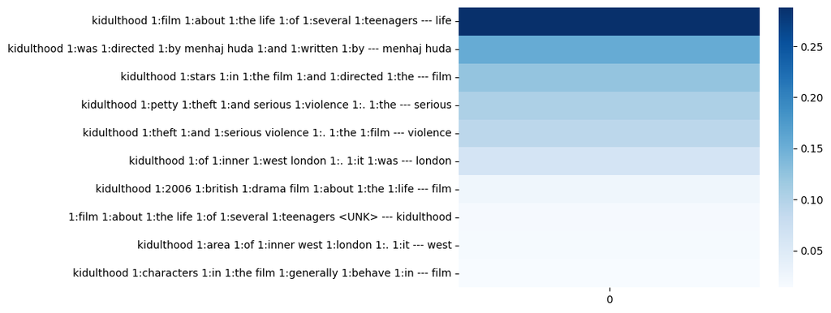

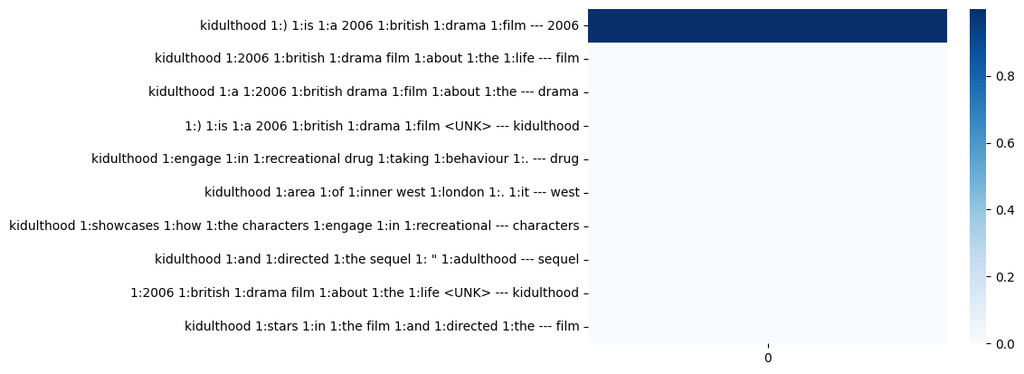

```
Predicted answer: drama
Correct answer: violence
```

```python
import matplotlib.pyplot as plt
import seaborn as sns

# Ejemplo interesante: 8622
EXAMPLE_ID = 8787
N_KEYS_TO_PLOT = 10

print('Número de ejemplos en test:', len(test_dataset))

def predict_example(example):
    question, q_length, key, key_num_length, key_word_length, value, candidate, cand_length, answer = pad_batch([example])

    question, q_length, key = question.to(device), q_length.to(device), key.to(device)
    key_num_length, key_word_length, value = key_num_length.to(device), key_word_length.to(device), value.to(device)
    candidate, cand_length, answer = candidate.to(device), cand_length.to(device), answer.to(device)
    pred_index = model.predict(question, q_length, key, key_num_length,
                            key_word_length, value, candidate, cand_length)

    return pred_index

def visualize_example(example_id):
  example = test_dataset[example_id]

  pred_index = predict_example(example)
  question, q_length, key, key_num_length, key_word_length, value, candidate, cand_length, answer = example
  candidate = candidate.to(device)

  print('Q:', ids_to_txt(question[1:]))
  for i in range(len(model.attentions)):
      attention = model.attentions[i][0][0].cpu().detach()
      max_values_indices = attention.argsort()[-N_KEYS_TO_PLOT:].flip(0)
      labels = []
      for key_i in max_values_indices:
          labels.append('{} --- {}'.format(ids_to_txt(key[key_i]), ids_to_txt([value[key_i]])))
      sns.heatmap(attention[max_values_indices].unsqueeze(1), cmap='Blues', yticklabels=labels)
      plt.show()

  print('Predicted answer:', ids_to_txt([candidate[pred_index]]))
  print('Correct answer:', ids_to_txt([candidate[answer]]))

visualize_example(EXAMPLE_ID)
```

```python
# === Búsqueda de errores del modelo (celda nueva) ===
errores = []
for ex_id in range(len(test_dataset)):
    example = test_dataset[ex_id]
    pred_index = predict_example(example)
    question, q_length, key, key_num_length, key_word_length, value, candidate, cand_length, answer = example
    pred = pred_index.item()
    if pred != answer.item():
        errores.append((
            ex_id,
            ids_to_txt(question[1:]),
            ids_to_txt([candidate[pred]]),       # lo que predijo
            ids_to_txt([candidate[answer]]),     # lo correcto
        ))
    if len(errores) >= 15:                       # corta tras 15 para no esperar
        break

print(f"Errores encontrados (primeros {len(errores)}):\n")
for ex_id, q, pred, correct in errores:
    print(f"[{ex_id}] Q: {q}")
    print(f"      pred: {pred}   |   correct: {correct}\n")
```

```
Errores encontrados (primeros 15):

[1] Q: describe what to expect when you're expecting ? 1:describe 1:what to expect when you're expecting 1: ?
      pred: what to expect when you're expecting   |   correct: pregnancy

[2] Q: describe deterrence ? 1:describe 1:deterrence 1: ?
      pred: directorial debut   |   correct: kevin pollak

[5] Q: describe rubin and ed ? 1:describe 1:rubin and ed 1: ?
      pred: crispin glover   |   correct: cat

[6] Q: describe the triumph of love ? 1:describe 1:the triumph of love 1: ?
      pred: ben kingsley   |   correct: 18th century

[7] Q: describe simon ? 1:describe 1:simon 1: ?
      pred: eddy terstall   |   correct: euthanasia

[8] Q: describe san francisco ? 1:describe 1:san francisco 1: ?
      pred: murder   |   correct: clark gable

[11] Q: describe across the bridge ? 1:describe 1:across the bridge 1: ?
      pred: across the bridge   |   correct: ken annakin

[12] Q: describe how i live now ? 1:describe 1:how i live now 1: ?
      pred: 2013   |   correct: saoirse ronan

[13] Q: describe bernie ? 1:describe 1:bernie 1: ?
      pred: murder   |   correct: albert dupontel

[14] Q: describe jaws 3-d ? 1:describe 1:jaws 3-d 1: ?
      pred: 1987   |   correct: franchise

[15] Q: describe high heels and low lifes ? 1:describe 1:high heels and low lifes 1: ?
      pred: action   |   correct: minnie driver

[16] Q: describe jesse james ? 1:describe 1:jesse james 1: ?
      pred: western   |   correct: henry king

[17] Q: describe old school ? 1:describe 1:old school 1: ?
      pred: todd phillips   |   correct: comedy

[19] Q: describe blinkytm ? 1:describe 1:blinkytm 1: ?
      pred: max records   |   correct: short

[20] Q: describe calamari union ? 1:describe 1:calamari union 1: ?
      pred: 1985   |   correct: comedy
```

```python
# === Top-5 candidatos por score para un ejemplo "describe" (celda nueva) ===
import torch.nn.functional as F

def top_k_candidates(example_id, k=5):
    example = test_dataset[example_id]
    batch = pad_batch([example])
    batch = [t.to(device) for t in batch]
    question, q_length, key, key_num_length, key_word_length, value, candidate, cand_length, answer = batch

    scores = model(question, q_length, key, key_num_length,
                   key_word_length, value, candidate, cand_length)  # log-probs [1, n_cands]
    scores = scores.masked_fill(model.gen_mask(candidate.shape[1], cand_length) == 0, float('-inf'))
    probs = F.softmax(scores, dim=-1)[0]
    topv, topi = probs.topk(k)

    correct_idx = answer.item()
    print(f"Q: {ids_to_txt(example[0][1:])}")
    print(f"Respuesta 'correcta' (ground-truth): {ids_to_txt([candidate[0][correct_idx]])}  "
          f"(prob={probs[correct_idx].item():.3f}, ranking #{(probs > probs[correct_idx]).sum().item()+1})\n")
    print(f"Top-{k} del modelo:")
    for rank, (v, i) in enumerate(zip(topv.tolist(), topi.tolist()), 1):
        marca = "  <-- ground-truth" if i == correct_idx else ""
        print(f"  #{rank}  {ids_to_txt([candidate[0][i]]):<30} prob={v:.3f}{marca}")
    print()

for ex_id in [17, 16, 20, 8]:   # old school, jesse james, calamari union, san francisco
    top_k_candidates(ex_id)
    print("=" * 70)
```

```
Q: describe old school ? 1:describe 1:old school 1: ?
Respuesta 'correcta' (ground-truth): comedy  (prob=0.000, ranking #2)

Top-5 del modelo:
  #1  todd phillips                  prob=1.000
  #2  luke wilson                    prob=0.000
  #3  old school                     prob=0.000
  #4  comedy                         prob=0.000  <-- ground-truth
  #5  2003                           prob=0.000

======================================================================
Q: describe jesse james ? 1:describe 1:jesse james 1: ?
Respuesta 'correcta' (ground-truth): henry king  (prob=0.000, ranking #2)

Top-5 del modelo:
  #1  western                        prob=1.000
  #2  henry hull                     prob=0.000
  #3  jesse james                    prob=0.000
  #4  1939                           prob=0.000
  #5  brian donlevy                  prob=0.000

======================================================================
Q: describe calamari union ? 1:describe 1:calamari union 1: ?
Respuesta 'correcta' (ground-truth): comedy  (prob=0.000, ranking #2)

Top-5 del modelo:
  #1  1985                           prob=1.000
  #2  asmo hurula                    prob=0.000
  #3  calamari union                 prob=0.000
  #4  surreal                        prob=0.000
  #5  kari heiskanen                 prob=0.000

======================================================================
Q: describe san francisco ? 1:describe 1:san francisco 1: ?
Respuesta 'correcta' (ground-truth): clark gable  (prob=0.000, ranking #2)

Top-5 del modelo:
  #1  murder                         prob=1.000
  #2  san francisco                  prob=0.000
  #3  barbary coast                  prob=0.000
  #4  clark gable                    prob=0.000  <-- ground-truth
  #5  gold                           prob=0.000

======================================================================
```

```python
# === Top-1 / Top-3 / Top-5 accuracy global en test (celda nueva) ===
import torch.nn.functional as F

def topk_accuracy(ks=(1, 3, 5), max_examples=2000):
    hits = {k: 0 for k in ks}
    total = 0
    for ex_id in range(min(len(test_dataset), max_examples)):
        example = test_dataset[ex_id]
        batch = [t.to(device) for t in pad_batch([example])]
        question, q_length, key, key_num_length, key_word_length, value, candidate, cand_length, answer = batch
        scores = model(question, q_length, key, key_num_length,
                       key_word_length, value, candidate, cand_length)
        scores = scores.masked_fill(model.gen_mask(candidate.shape[1], cand_length) == 0, float('-inf'))
        gt = answer.item()
        ranking = (scores[0] > scores[0][gt]).sum().item()  # cuántos candidatos superan al gt
        for k in ks:
            if ranking < k:        # el gt está dentro del top-k
                hits[k] += 1
        total += 1
    print(f"Evaluado sobre {total} ejemplos de test:")
    for k in ks:
        print(f"  Top-{k} accuracy: {hits[k]/total:.3f}")

topk_accuracy()
```

```
Evaluado sobre 2000 ejemplos de test:
  Top-1 accuracy: 0.581
  Top-3 accuracy: 0.741
  Top-5 accuracy: 0.799
```

```python
import numpy as np
np.random.seed(1)
idxs = np.random.choice(len(test_dataset), 2000, replace=False)  # muestra ALEATORIA
hits1 = 0
for ex_id in idxs:
    example = test_dataset[int(ex_id)]
    batch = [t.to(device) for t in pad_batch([example])]
    q,ql,k,knl,kwl,v,c,cl,a = batch
    s = model(q,ql,k,knl,kwl,v,c,cl)
    s = s.masked_fill(model.gen_mask(c.shape[1], cl)==0, float('-inf'))
    hits1 += int((s[0]>s[0][a.item()]).sum().item() < 1)
print(f"Top-1 sobre muestra ALEATORIA de 2000: {hits1/2000:.3f}")
```

```
Top-1 sobre muestra ALEATORIA de 2000: 0.683
```

```
================================================================================
EXAMPLE_ID = 2222  |  factual fácil — who directed men with brooms? (paul gross)
================================================================================
Q: who directed the film men with brooms ? 1:who 1:directed 1:the 1:film 1:men with brooms 1: ?
```

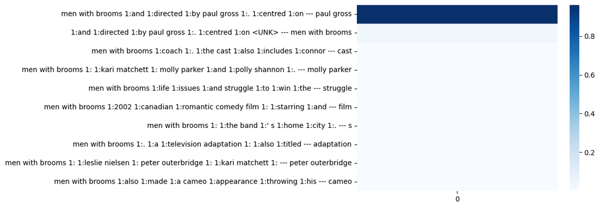

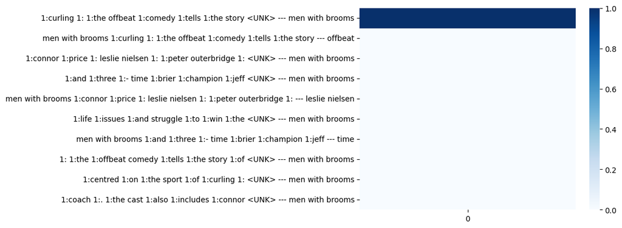

```
Predicted answer: paul gross
Correct answer: paul gross


================================================================================
EXAMPLE_ID = 4859  |  género — what was the genre of safety not guaranteed? (comedy)
================================================================================
Q: what was the genre of safety not guaranteed ? 1:what 1:was 1:the 1:genre 1:of 1:safety not guaranteed 1: ?
```

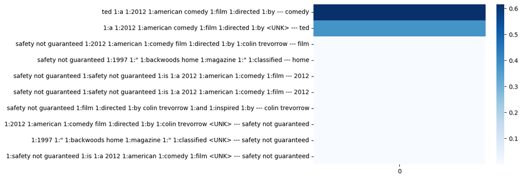

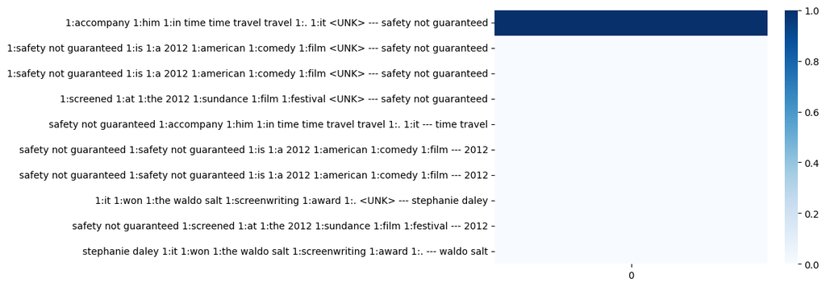

```
Predicted answer: comedy
Correct answer: comedy


================================================================================
EXAMPLE_ID = 2292  |  posible fallo — who directed the film heat? (paul morrissey)
================================================================================
Q: who directed the film heat ? 1:who 1:directed 1:the 1:film 1:heat 1: ?
```

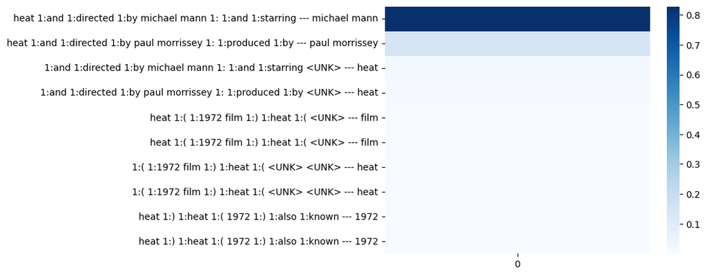

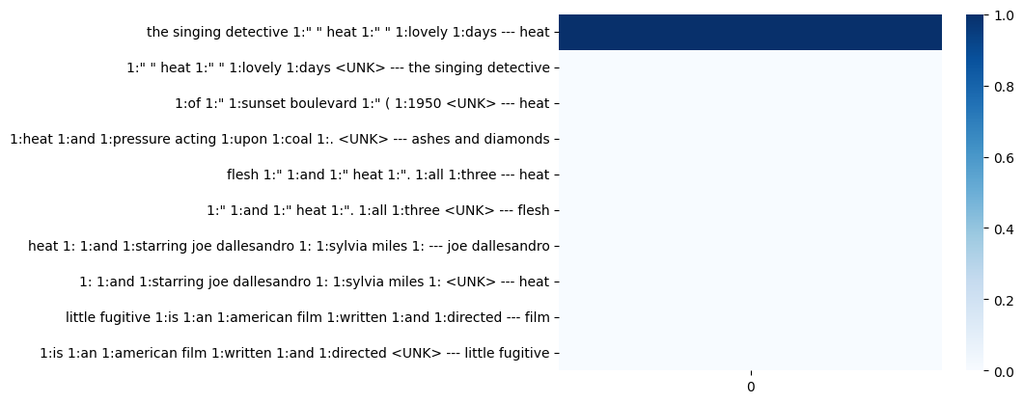

```
Predicted answer: michael mann
Correct answer: paul morrissey


================================================================================
EXAMPLE_ID = 7263  |  pregunta abierta — which films described by radiation? (hulk)
================================================================================
Q: which films can be described by radiation ? 1:which 1:films 1:can 1:be 1:described 1:by 1:radiation 1: ?
```

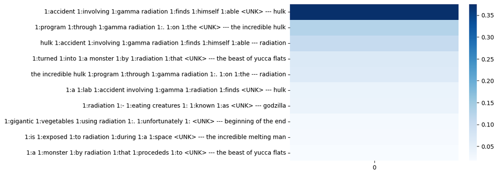

[figure not shown]

```
Predicted answer: hulk
Correct answer: hulk


================================================================================
EXAMPLE_ID = 2435  |  language — what language is little white lies in? (french)
================================================================================
Q: what language is little white lies in ? 1:what 1:language 1:is 1:little white lies 1:in 1: ?
```

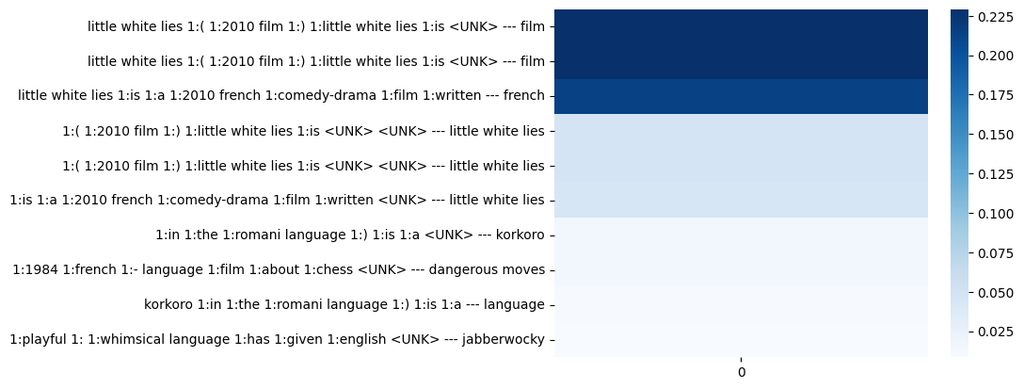

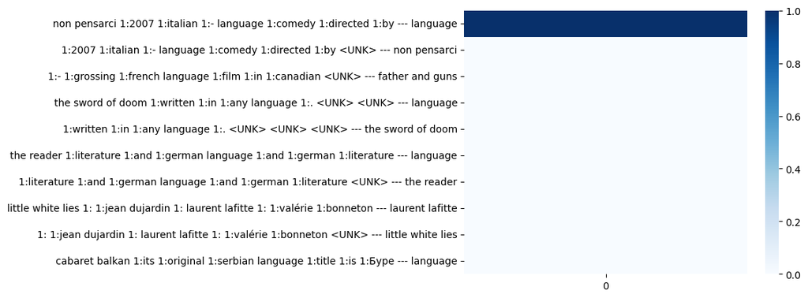

```
Predicted answer: french
Correct answer: french
```

```python
# === Casos de contraste ===
# visualize_example y predict_example ya fueron definidas en la celda 63

casos = {
    2222: "factual fácil — who directed men with brooms? (paul gross)",
    4859: "género — what was the genre of safety not guaranteed? (comedy)",
    2292: "posible fallo — who directed the film heat? (paul morrissey)",
    7263: "pregunta abierta — which films described by radiation? (hulk)",
    2435: "language — what language is little white lies in? (french)",
}

for ex_id, desc in casos.items():
    print("=" * 80)
    print(f"EXAMPLE_ID = {ex_id}  |  {desc}")
    print("=" * 80)
    visualize_example(ex_id)
    print("\n")
```

# Cierre — Análisis de experimentos adicionales

Mini-estudio del comportamiento del modelo KV-MemNN, construido con 5 experimentos ejecutados sobre el notebook (más allá de las celdas base), usando el checkpoint pre-entrenado (`best_state.pt`, ~69% accuracy en test).

## Resumen de los 5 experimentos

[output not shown]

## Tesis unificada

> **El "31% de error" del modelo es engañoso. Una parte sustancial no son errores de capacidad, sino artefactos de evaluación (ground-truth single-answer sobre preguntas multi-respuesta).**

Cadena de evidencia:

1. Los errores se concentran en `describe X` (exp. 2), preguntas subespecificadas que no indican qué faceta de la película se quiere.
2. Para esas preguntas, el modelo recupera correctamente TODAS las facetas (exp. 3: el top-5 entero es ficha técnica válida — director, actores, género, año, temas).
3. El preprocesamiento (celda 31, `first_answer = answer[0]`) fijó arbitrariamente UNA faceta como ground-truth; la métrica top-1 exact-match castiga al modelo por elegir otra faceta igualmente válida.
4. El salto top-1 → top-3 de +16 puntos (exp. 4) mide directamente cuánta "tasa de error" es en realidad multi-validez.

## Detalle por experimento

### Exp. 2 — Búsqueda de errores

Los primeros 15 errores fueron TODOS preguntas `describe X`. Dos categorías:

- **A (13/15):** el modelo predijo una descripción válida distinta del ground-truth arbitrario (ej.: old school → "todd phillips", gt "comedy"; jesse james → "western", gt "henry king").
- **B (2/15):** "trivial answer" — el modelo devolvió el TÍTULO de la película misma (ej.: "describe across the bridge" → predijo "across the bridge", gt "ken annakin").

### Exp. 3 — Top-5 candidatos por score

| Película | #1 | #2 | #3 | #4 | #5 |
| --- | --- | --- | --- | --- | --- |
| old school | todd phillips (dir) | luke wilson (actor) | old school (título) | comedy (gt) | 2003 (año) |
| jesse james | western (género) | henry hull (actor) | jesse james (título) | 1939 (año) | brian donlevy (actor) |
| calamari union | 1985 (año) | asmo hurula (actor) | calamari union (título) | surreal (tema) | kari heiskanen (actor) |
| san francisco | murder (tema) | san francisco (título) | barbary coast (tema) | clark gable (gt) | gold (tema) |

- Cada candidato del top-5 es una descripción legítima → el modelo recupera bien.
- prob=1.000 en el #1 → sobreconfianza / mala calibración (producto punto sin temperatura satura el softmax).
- El título de la película aparece en el top-3 sistemáticamente (sesgo "trivial answer" del esquema key/value: entradas `__movie__` con value=título matchean preguntas que repiten el título).

### Exp. 4 — Top-k accuracy (primeros 2000, sin shuffle)

| Métrica | Accuracy | Δ |
| --- | --- | --- |
| Top-1 | 0.581 | — |
| Top-3 | 0.741 | +0.160 |
| Top-5 | 0.799 | +0.058 |

+16 pts al permitir top-3: ~16% de las preguntas tenían el ground-truth en posición #2–#3. El retorno marginal decae (top-3→top-5 solo +5.8 pts): el modelo concentra el acierto en las primeras posiciones, coherente con la sobreconfianza.

### Exp. 5 — Muestra aleatoria

| Evaluación | Top-1 |
| --- | --- |
| Primeros 2000 (sin shuffle) | 0.581 |
| Muestra aleatoria de 2000 | 0.683 |

+10 pts solo por barajar → el `test_dataset` está ordenado por tipo de pregunta, con los `describe X` (los más difíciles) agrupados al inicio. El 0.683 aleatorio ≈ 0.69 del test completo confirma la consistencia de la evaluación.

## Conexión con sistemas de matching / record linkage (MDM, FHIR)

Caso de manual de **ground-truth incompleto** en evaluación de retrieval/matching:

- Si el gold standard marca un único match válido pero existen varios duplicados legítimos, precisión y recall medidos subestiman al sistema real.
- Firma diagnóstica: brecha top-1 vs top-k. Si recuperás bien pero el top-1 exact-match es bajo, sospechá multi-validez en el ground-truth antes de culpar al modelo.
- La sobreconfianza del softmax sin temperatura es la razón por la que un scorer (p. ej. GBM) necesita calibración (Platt / isotónica) antes de fijar umbrales de decisión.

# Actividades

Elija **tres** de las siguientes actividades y responda. Solo se considerarán en la nota las **dos** con mejor puntaje.

Si responde más de tres preguntas solo se corregirán tres (considerando dentro de la nota solo las dos mejores).

Todas las actividades son respecto al modelo Key-Value Memory Network

## Actividad 1

Indique una forma en que cree que podría obtener/generar mejores embeddings para cada entrada de la KB. Considere que ya se separaron los tokens y tiene una lista de índices de tokens para cada entrada.

```python
R = "Hoy cada entrada se representa como el PROMEDIO (Bag-of-Words) de los embeddings de sus tokens, lo que pierde el orden de las palabras y pondera igual a stopwords y entidades. Mejoras posibles: 1) Ponderar tokens en vez de promediar uniforme (TF-IDF o atencion/self-attention pooling), para que la entidad y la relacion dominen sobre las stopwords. 2) Incorporar el orden con positional encoding (como en el paper de Memory Networks) o codificando cada entrada con un BiLSTM/GRU, asi se distinguen relaciones direccionales (X dirige Y vs Y dirige X). 3) Usar un encoder contextual (Transformer / BERT-BETO) para capturar composicion e interacciones entre tokens. 4) Inicializar los embeddings con vectores preentrenados (word2vec/GloVe), util porque la matriz es enorme (186.841 tokens) y muchos aparecen poco. Evidencia: la accuracy top-1 (0.58) sube a top-3 (0.74), lo que sugiere que mejores representaciones por entrada recuperarian buena parte de ese margen." # @param{type: "string"}
```

## Actividad 2

A continuación se muestran algunos casos hipotéticos en que se agregan entradas a la KB después de haber entrenado el modelo. En cada caso, indique si el modelo sería capaz de responder a preguntas relacionadas con estas nuevas entradas. Fundamente su respuesta.

1. Añadir nuevas entradas con entidades distintas a las que el modelo vió durante su entrenamiento

```python
R = "Depende de como se tokenice la entidad. Si cada entidad es un token atomico (como en el preprocesamiento simple del notebook), una entidad nueva no tiene fila en la matriz de embeddings: cae en UNK/<NULL> o seria un embedding aleatorio sin entrenar, por lo que el matching por atencion y el value devuelto son ruido y NO puede responder. Si en cambio la entidad se separa en palabras (el preprocesamiento usado para los .pkl), sus subtokens pueden existir en el vocabulario y la entrada tendria una representacion (promedio de esos embeddings), pero de calidad no garantizada porque el modelo nunca aprendio esa combinacion. En el caso general la respuesta es NO de forma confiable: es el limite PARAMETRICO del modelo, el conocimiento de como representar un token vive en los pesos y no se actualiza solo agregando datos a la KB; haria falta (re)entrenar el embedding del nuevo token." # @param{type: "string"}
```

2. Añadir nuevas entradas agregando nueva información sobre películas que ya están en la KB. Esta nueva información menciona solamente entidades que ya estaban en la KB y el modelo vió durante su entrenamiento.

```python
R = "SI puede responder. La KB en KV-MemNN es EXTERNA y NO-PARAMETRICA: agregar una entrada es solo anadir un par (key, value) a la memoria sobre la que se hace atencion, sin tocar los pesos. Como la nueva informacion usa solo entidades/tokens que el modelo YA vio, todos sus tokens tienen embeddings entrenados y el key addressing y el value reading operan igual que con cualquier entrada original. Lo unico necesario a nivel de implementacion es reindexar la nueva entrada en el indice invertido del blocker para que sea recuperada como candidato, pero eso es ingenieria de datos, no reentrenamiento del modelo. Esta es la ventaja central de la memoria externa frente a un modelo puramente parametrico (ej. un RNN que guarda el conocimiento en sus pesos): se puede actualizar el conocimiento sin reentrenar." # @param{type: "string"}
```

## Actividad 3

Suponga que tiene ahora una base de datos de tuplas con las forma (sujeto, relación, objeto), por ejemplo (empanada, comida_típica_de, Chile), y tiene que construir una base de conocimiento estilo key-value. Indique qué utilizaría como keys y qué como values.

```python
R = "Usaria como KEY la concatenacion (sujeto + relacion) y como VALUE el objeto. Para la tupla del ejemplo: key = (empanada, comida_típica_de) y value = Chile. Asi, una pregunta que menciona el sujeto y la relacion puede recuperar por atencion (key addressing) la entrada correspondiente y el modelo devuelve el objeto como respuesta. Es el esquema que propone el paper KV-MemNN para bases de conocimiento de tripletas (sujeto, relacion, objeto)." # @param{type: "string"}
```

Usando solamente la entrada (empanada, comida_típica_de, Chile) y **considerando la forma de definir keys y values que propuso en la pregunta anterior**, cree usted que el modelo podría contestar las siguientes dos preguntas? Explique por qué cree que sí o que no, y en caso de que no se pueda indique qué podría hacer (a nivel de datos o de modelo) para que sí pueda responder ambas preguntas (**Hint:** puede crear nuevas tuplas a partir de las ya existentes):

1. ¿De qué país es la empanada una comida típica?

```python
R = "SI puede. La pregunta menciona el sujeto (empanada) y la relacion (de que pais es comida típica), que es justo lo que compone la key (empanada, comida_típica_de). El key addressing matchea esa entrada y el modelo devuelve su value, Chile, que es exactamente la respuesta correcta." # @param{type: "string"}
```

2. ¿Cuál es una comida típica de Chile?

```python
R = "NO puede con la tupla original, por dos razones: (1) la respuesta esperada (empanada) es el SUJETO, que quedo dentro de la key, y el modelo solo devuelve VALUES, nunca partes de la key; (2) la pregunta menciona Chile, que esta en el value y no en la key, asi que el key addressing tampoco matchea bien. Solucion a nivel de datos (sin reentrenar): crear la tupla INVERSA a partir de la existente, (Chile, comida_típica_de_inversa, empanada), es decir key = (Chile, relacion_inversa) y value = empanada. Asi la pregunta sobre Chile matchea la nueva key y devuelve empanada. Esto es lo que el paper KV-MemNN llama 'doblar la KB' agregando las relaciones inversas para permitir recuperacion en ambas direcciones." # @param{type: "string"}
```

## Actividad 4

A continuación hay un ejemplo (pregunta) inventado que no está en el dataset (en ningún split). Haga el preprocesamiento necesario a este ejemplo en la celda que se indica más adelante. Asegúrese de que corra el código de la celda siguiente, que debería mostrar la visualización del modelo al pasarle este ejemplo y contestar correctamente.

Para el preprocesamiento puede basarse en el código de las secciones "Preprocesar datos" y "Modelo y dataloaders", y utilizar las funciones que están ahí.

IMPORTANTE: Para que este código funcione debe haber corrido previamente todas las celdas de este notebook (menos la del entrenamiento)

```python
token_dict = {token: i for i, token in enumerate(dict_txt)}
new_question_txt = '<NULL> who directed doomsday ? 1:who 1:directed 1:doomsday 1: ?'
new_question = [token_dict[token] for token in new_question_txt.split()]
new_answer = [token_dict['neil marshall']]
new_q_orig = [new_question]
new_a_orig = [new_answer]
```

```python
# AQUÍ VA SU RESPUESTA
new_q, new_key, new_value, new_cand, new_a = gen_candidates(new_q_orig, new_a_orig)
new_key = pad_all_keys(new_key)
new_q_word_lengths, new_key_num_lengths, new_key_word_lengths, new_cand_lengths = get_data_lengths(
    new_q, new_key, new_cand
)
```

```
Q: who directed doomsday ? 1:who 1:directed 1:doomsday 1: ?
```

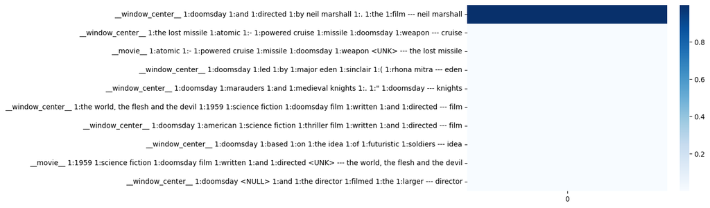

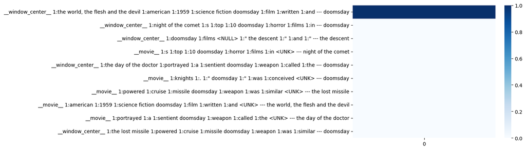

```
Predicted answer: neil marshall
Correct answer: neil marshall
```

```python
test_dataset = list(zip(
    # ESTAS SON LAS VARIABLES QUE DEBE GENERAR SU CÓDIGO
    new_q, new_q_word_lengths, new_key, new_key_num_lengths, new_key_word_lengths,
    new_value, new_cand, new_cand_lengths, new_a
))
visualize_example(0)
```